# Creating code embedding matrix

For PHS7045

Yidan Zhang

## Introduction

- Word embedding has become a significant topic in natural language processing.
- GloVe (Global Vectors for Word Representation) is a method that incorporates global statistical information by capturing word-to-word co-occurrence patterns across the entire corpus.
- One application of embedding in healthcare research is in medical codes (ICD for diagnosis, CPT for procedure and etc.), which can provide valuable support for downstream analysis.
- The goal is to develop a package that implements the GloVe algorithm to generate code embedding matrices for EHR data.

## Solution Plan

- The most computationally expensive part of the GloVe algorithm is constructing the co-occurrence matrix. For a given context window, the function must iterate through each patient to count code pair co-occurrences.
- The second step is to use the co-occurrence matrix to create the pointwise mutual information (PMI) or SPPMI (shifted positive PMI) matrix.
- The third step is to use truncate singular value decomposition (SVD) to factorize the PMI/SPPMI matrix and generate lower-dimensional embeddings for the codes based on a user defined length of singular values and vectors.
- One approach to help users who work on ICD codes to determine the optimal embedding vector length is to evaluate the performance of the embedding matrix by predicting phecode-based classification accuracy.

## Preliminary Result

- The data used to test the package is the ‘diagnosis_icd’ file from the MIMIC-III clinical dataset.

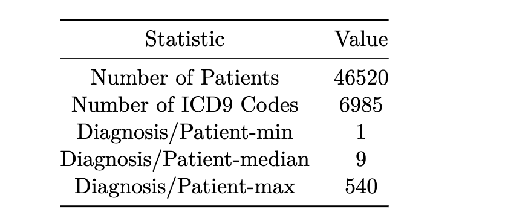

- The data employed for this presentation is available in the repository and consists of a random sample of 1,000 subjects, resulting in a total of 13,623 observations from the original dataset.

## Function

cooccur_optimized (data, id, code, time, window = NA)

get_SG (matrix)

construct_pmi (coccur,singletons,my.smooth)

construct_sppmi (pmi,k)

A sample of the co-occurrence function’s output is shown below:

```
      V3000 76503 769 77181 7742 76523 7766 77081
V3000     0     2   7     3   15     2    2     6
76503     2     0   3     1    3     3    2     1
769       7     3   0     2   20     3    7    10
77181     3     1   2     0    4     1    2     3
7742     15     3  20     4    2     3    7    16
76523     2     3   3     1    3     0    2     1
```

## Optimization

The goal of the package is not only to provide practical functions but also to incorporate the optimization techniques we learned in this class, reducing computational overhead and enhancing performance.

```
Unit: seconds
      expr       min       lq      mean    median        uq       max neval
   initial 10.526573 10.57881 10.638930 10.590525 10.661386 10.837356     5
 optimized  2.886455  2.90188  3.071169  2.915126  2.971536  3.680846     5
```